# Module 3, Lesson 1: The basics of the grammar of graphics

In this first lesson of Module 3, you were introduced to the `ggplot2` package, which allows you to create publication-quality graphics with relative ease. The package is part of the `tidyverse` and so is already installed and available to you on your computer. Open the R project called `Lessons.Rproj` and a blank R script. As always, you’ll first need to load the necessary packages into the current R session:

```r
library(tidyverse)
```

## The `ggplot` template

Here is the basic template for creating plots in ggplot:

```r
ggplot(data = <DATA>) +
  geom_<GEOMNAME>(mapping = aes(<MAPPINGS>))
```

It is only a *template*, and it won’t run correctly until you replace the bracketed expressions, namely `<DATA>`, `<GEOMNAME>`, and `<MAPPINGS>`, with appropriate R code.

The `<DATA>` expression should be replaced with the name of a dataset that exists in your R session. In our guided practice, we exclusively use `growth_data`.

The `<GEOMNAME>` expression should be replaced with any valid geometric (geom) object. Perhaps most common is `geom_point`, which creates a scatterplot, i.e. plots individual points. Many other choices exist too, some of which we’ll learn about in this module.

The `<MAPPINGS>` expression should be replaced by one or more equations, separated by commas, that *map* certain variables in your dataset to certain aesthetics. The `x` and `y` aesthetics, respectively controlling the x-axis and y-axis, are the most common aesthetics, and there are several others.

Note also that when using multiple `ggplot2`-specific functions, you *add* the functions together using the `+` sign (not the `%>%` operator as you might expect).

Putting this all together, we can create a simple scatterplot of the infant growth data, plotting the height measurements on the y-axis against the weight measurements on the x-axis:

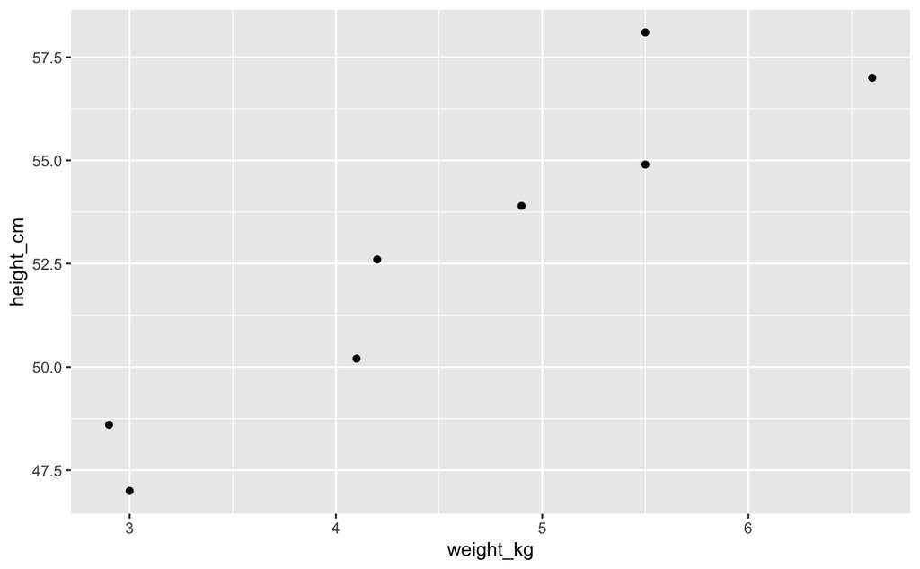